# HW5 - Problem 3 - Orange Juice classification

misken

March 26, 2018

# Problem 3 - Predicting orange juice purchases

The dataset is available as part of the ISLR package. You can see the documentation for that package or the following link describes the OJ dataset - https://rdrr.io/cran/ISLR/man/OJ.html.

**SUGGESTION**: See the material available in Downloads_StatModels2 from the session on classification models in R. In particular, the folder on logistic regression and the example in the folder intro_class_HR/ will be useful.

## Data prep

We’ll do a little data prep to set things up so that we are trying to predict whether or not the customer purchased Minute Maid (vs Citrus Hill.) Just run the following chunks to load the dataset, do some data prep and then partition the data into training and test sets.

```r
ojsales <- (ISLR::OJ)
```

Clean up the storeid related fields. Drop Store7 field.

```r
ojsales$StoreID <- as.factor(ojsales$StoreID)

# Create a new variable to act as the response variable.
ojsales$MM <- as.factor(ifelse(ojsales$Purchase=="MM",1,0))
```

Now we’ll just take a subset of the columns as there are a few that contain the same information. Remember, the new column `MM` is the one we are trying to predict.

```r
ojsales_subset <- ojsales[, c(19, 3:13, 15:17)]
```

Just run this chunk to create training and test datasets. This way we’ll all be working with the same datasets. Notice that the test set is 10% of the full dataset.

```r
set.seed(167)
sample_size <- ceiling(0.10 * nrow(ojsales))
testrecs <- sample(nrow(ojsales_subset),sample_size)
ojsales_test <- ojsales_subset[testrecs,]
ojsales_train <- ojsales_subset[-testrecs,]  # Negative in front of vector means "not in"
rm(ojsales_subset, ojsales) # No sense keeping a copy of the entire dataset around
```

## Your job

You should build at least two classification models to try to predict MM. Our error metric will be overall accuracy.

Obviously, `ojsales_train` is your training dataset. After fitting each model, use the `caret::confusionMatrix` function to create a confusion matrix for each of the models based on the training data.

You should at least try the following two techniques: - logistic regression - a simple decision tree

**HACKER EXTRA:** Try additional techniques such as random forest, k-nearest neighbor or others.

Then use the `predict()` function to make classification predictions on the test dataset and use `caret::confusionMatrix` to create a confusion matrix for each of the models for the predictions.

Summarize your results. - Which technique performed the best in terms of overall accuracy? - Which technique had the best sensitivity score? - How did accuracy differ for the training and test datasets for each model? - Is their any evidence of overfitting?

## Load Packages

```r
library(e1071)
library(caret)
```

```r
library(rpart)
library(rpart.plot)
library(RColorBrewer)
library(randomForest)
library(ggplot2)
library(class)
library(dplyr)
```

## Logistic Regression

```r
oj_log <- glm(MM ~ PriceDiff + LoyalCH + PctDiscMM, data=ojsales_train, family=binomial(link="logit"))
summary(oj_log)
```

```
##
## Call:
## glm(formula = MM ~ PriceDiff + LoyalCH + PctDiscMM, family = binomial(link = "logit"),
##     data = ojsales_train)
##
## Deviance Residuals:
##     Min       1Q   Median       3Q      Max
## -2.7306  -0.5772  -0.2493   0.5828   2.7719
##
## Coefficients:
##             Estimate Std. Error z value Pr(>|z|)
## (Intercept)   3.5242     0.2874  12.262  < 2e-16 ***
## PriceDiff    -4.0454     0.6592  -6.137 8.42e-10 ***
## LoyalCH      -6.1522     0.3952 -15.567  < 2e-16 ***
## PctDiscMM    -3.6769     1.6360  -2.247   0.0246 *
## ---
## Signif. codes:  0 '***' 0.001 '**' 0.01 '*' 0.05 '.' 0.1 ' ' 1
##
## (Dispersion parameter for binomial family taken to be 1)
##
##     Null deviance: 1293.58  on 962  degrees of freedom
## Residual deviance:  768.67  on 959  degrees of freedom
## AIC: 776.67
##
## Number of Fisher Scoring iterations: 5
```

> From a process of trial and error, it appears most of these variables do not add to the accuracy of the model. That is why I have only chosen three that seem relatively significant.

```r
log_fit <- (oj_log$fit > 0.5) * 1
caret::confusionMatrix(oj_log$y, log_fit, positive="1")
```

```
## Confusion Matrix and Statistics
##
##           Reference
## Prediction   0   1
##          0 509  72
##          1  93 289
##
##                Accuracy : 0.8287
##                  95% CI : (0.8033, 0.8519)
##     No Information Rate : 0.6251
##     P-Value [Acc > NIR] : <2e-16
##
##                   Kappa : 0.6386
##  Mcnemar's Test P-Value : 0.1195
##
##             Sensitivity : 0.8006
##             Specificity : 0.8455
##          Pos Pred Value : 0.7565
##          Neg Pred Value : 0.8761
##              Prevalence : 0.3749
##          Detection Rate : 0.3001
##    Detection Prevalence : 0.3967
##       Balanced Accuracy : 0.8230
##
##        'Positive' Class : 1
##
```

> The fit accuracy for the model is 0.8287.

```r
predict_log <- predict(oj_log, newdata=ojsales_test, type="response")
log_predict <- (predict_log > 0.5) * 1

caret::confusionMatrix(ojsales_test$MM, log_predict, positive ="1")
```

```
## Confusion Matrix and Statistics
##
##           Reference
## Prediction  0  1
##          0 66  6
##          1  7 28
##
##                Accuracy : 0.8785
##                  95% CI : (0.8012, 0.9337)
##     No Information Rate : 0.6822
##     P-Value [Acc > NIR] : 2.093e-06
##
##                   Kappa : 0.722
##  Mcnemar's Test P-Value : 1
##
##             Sensitivity : 0.8235
##             Specificity : 0.9041
##          Pos Pred Value : 0.8000
##          Neg Pred Value : 0.9167
##              Prevalence : 0.3178
##          Detection Rate : 0.2617
##    Detection Prevalence : 0.3271
##       Balanced Accuracy : 0.8638
##
##        'Positive' Class : 1
##
```

> The predictive accuracy for the model is 0.8785. This is higher than accuracy for the train. Hmm, normally accuracy for test is supposed to be lower than train. This may have to do with the fact that we are training on much more data than we are tetsing on.

## Simple Decision Tree

> For the simple decision tree, I kept the same three variables in the model to see how it compares to logistic regression. I also do not want run into the problem of overfitting.

```r
oj_tree <- rpart(MM ~ PriceDiff + LoyalCH + PctDiscMM, data=ojsales_train, method="class")
oj_tree
```

```
## n= 963
##
## node), split, n, loss, yval, (yprob)
##       * denotes terminal node
##
##  1) root 963 382 0 (0.6033229 0.3966771)
##    2) LoyalCH>=0.5036 536  74 0 (0.8619403 0.1380597)
##      4) PriceDiff>=-0.39 504  54 0 (0.8928571 0.1071429) *
##      5) PriceDiff< -0.39 32  12 1 (0.3750000 0.6250000)
##       10) LoyalCH>=0.9748025 7   1 0 (0.8571429 0.1428571) *
##       11) LoyalCH< 0.9748025 25   6 1 (0.2400000 0.7600000) *
##    3) LoyalCH< 0.5036 427 119 1 (0.2786885 0.7213115)
##      6) LoyalCH>=0.2761415 223  92 1 (0.4125561 0.5874439)
##       12) PriceDiff>=0.05 129  56 0 (0.5658915 0.4341085) *
##       13) PriceDiff< 0.05 94  19 1 (0.2021277 0.7978723) *
##      7) LoyalCH< 0.2761415 204  27 1 (0.1323529 0.8676471) *
```

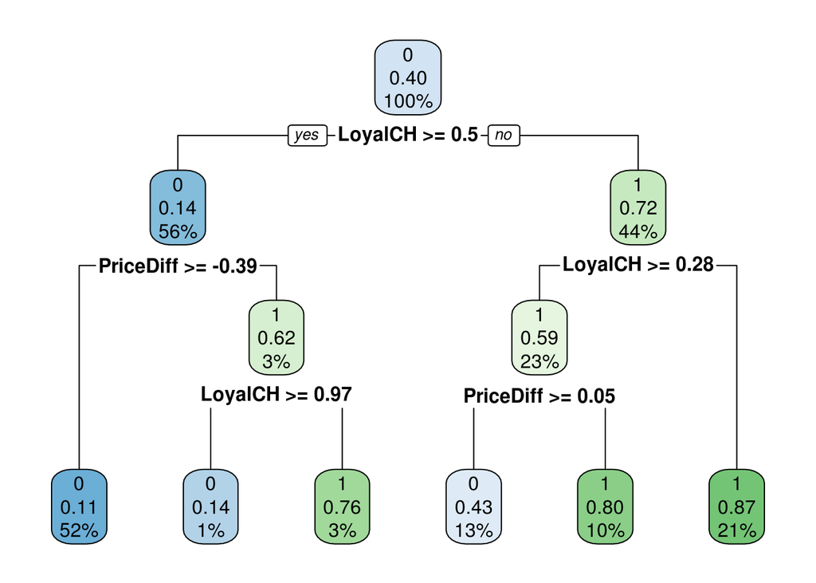

```r
rpart.plot(oj_tree)
```

```r
caret::confusionMatrix(predict(oj_tree, type="class"),
                       ojsales_train$MM, positive = "1")
```

```
## Confusion Matrix and Statistics
##
##           Reference
## Prediction   0   1
##          0 529 111
##          1  52 271
##
##                Accuracy : 0.8307
##                  95% CI : (0.8055, 0.8539)
##     No Information Rate : 0.6033
##     P-Value [Acc > NIR] : < 2.2e-16
##
##                   Kappa : 0.6368
##  Mcnemar's Test P-Value : 5.548e-06
##
##             Sensitivity : 0.7094
##             Specificity : 0.9105
##          Pos Pred Value : 0.8390
##          Neg Pred Value : 0.8266
##              Prevalence : 0.3967
##          Detection Rate : 0.2814
##    Detection Prevalence : 0.3354
##       Balanced Accuracy : 0.8100
##
##        'Positive' Class : 1
##
```

> The fit accuracy for this model is 0.8307.

```r
predict_tree <- predict(oj_tree, ojsales_test, type="class")
```

```r
caret::confusionMatrix(predict_tree, ojsales_test$MM, positive = "1")
```

```
## Confusion Matrix and Statistics
##
##           Reference
## Prediction  0  1
##          0 69 11
##          1  3 24
##
##                Accuracy : 0.8692
##                  95% CI : (0.7902, 0.9266)
##     No Information Rate : 0.6729
##     P-Value [Acc > NIR] : 2.77e-06
##
##                   Kappa : 0.6842
##  Mcnemar's Test P-Value : 0.06137
##
##             Sensitivity : 0.6857
##             Specificity : 0.9583
##          Pos Pred Value : 0.8889
##          Neg Pred Value : 0.8625
##              Prevalence : 0.3271
##          Detection Rate : 0.2243
##    Detection Prevalence : 0.2523
##       Balanced Accuracy : 0.8220
##
##        'Positive' Class : 1
##
```

> The predictive accuracy for this model is 0.8692. Again, this is higher for test than train.

## **HACKER EXTRA: Bagging**

> Since this model only splits on some variables, let’s just use all of the variables. Since this is bagging, ‘mtry’ is set to 14, which is all of the variables.

```r
oj_bag <- randomForest(MM ~ StoreID + PriceCH + PriceMM +
                        DiscCH + DiscMM + SpecialCH +
                        SpecialMM + LoyalCH + SalePriceMM +
                        SalePriceCH + PriceDiff + PctDiscMM +
                        PctDiscCH + ListPriceDiff,
                      data=ojsales_train,
                      mtry=14,
                      importance=TRUE,
                      na.action = na.omit)
oj_bag
```

```
##
## Call:
##  randomForest(formula = MM ~ StoreID + PriceCH + PriceMM + DiscCH +      DiscMM + SpecialCH + SpecialMM + LoyalCH + SalePriceMM +      SalePriceCH + PriceDiff + PctDiscMM + PctDiscCH + ListPriceDiff,      data = ojsales_train, mtry = 14, importance = TRUE, na.action = na.omit)
##                Type of random forest: classification
##                      Number of trees: 500
## No. of variables tried at each split: 14
##
##         OOB estimate of  error rate: 21.91%
## Confusion matrix:
##     0   1 class.error
## 0 467 114   0.1962134
## 1  97 285   0.2539267
```

```r
acc_bag <- (470 + 281) / (470 + 101 + 111 + 281)
sprintf("Fit accuracy = %.4f" , acc_bag)
```

```
## [1] "Fit accuracy = 0.7799"
```

> Fit accuracy for this model is lower than the previous ones. It could have to do with using all of the variables instead of only the significant ones. Let’s check which ones are important, or significant, according to this model.

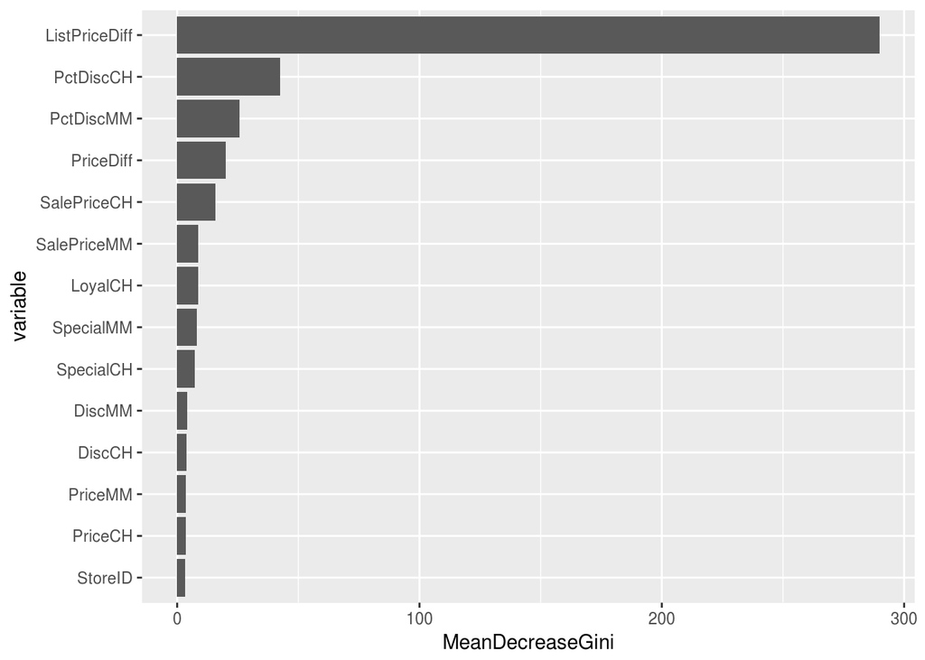

```r
# Create dataframe based on importance and order by MeanDecreaseGini
df_imp <- arrange(as.data.frame(oj_bag$importance),
                  MeanDecreaseGini)
# Add variable column
df_imp$variable <- as.factor(names(oj_bag$importance[,1]))

# Reorder the levels of the variable factor by MeanDecreaseGini
df_imp <- within(df_imp, variable <- reorder(variable, MeanDecreaseGini))

#Plot it
ggplot(data=df_imp) + geom_bar(aes(x=variable, y=MeanDecreaseGini),
                               stat = "identity") + coord_flip()
```

```r
predict_bag <- predict(oj_bag, ojsales_test, type="class")
caret::confusionMatrix(predict_bag, ojsales_test$MM, positive = "1")
```

```
## Confusion Matrix and Statistics
##
##           Reference
## Prediction  0  1
##          0 61  9
##          1 11 26
##
##                Accuracy : 0.8131
##                  95% CI : (0.7262, 0.8819)
##     No Information Rate : 0.6729
##     P-Value [Acc > NIR] : 0.0009139
##
##                   Kappa : 0.5815
##  Mcnemar's Test P-Value : 0.8230633
##
##             Sensitivity : 0.7429
##             Specificity : 0.8472
##          Pos Pred Value : 0.7027
##          Neg Pred Value : 0.8714
##              Prevalence : 0.3271
##          Detection Rate : 0.2430
##    Detection Prevalence : 0.3458
##       Balanced Accuracy : 0.7950
##
##        'Positive' Class : 1
##
```

> The predictive accuracy of this model is 0.8131, which is still better than the train, but not close to either my logistic or decision tree models.

## **HACKER EXTRA: Random Forest**

> Since only a few of the variables seem to be important, I am only setting the ‘mtry’ paramter to 3. This will likely weed out the insignificant variables.

```r
oj_rf <- randomForest(MM ~ StoreID + PriceCH + PriceMM +
                        DiscCH + DiscMM + SpecialCH +
                        SpecialMM + LoyalCH + SalePriceMM +
                        SalePriceCH + PriceDiff + PctDiscMM +
                        PctDiscCH + ListPriceDiff,
                      data=ojsales_train,
                      mtry=3,
                      importance=TRUE,
                      na.action = na.omit)
oj_rf
```

```
##
## Call:
##  randomForest(formula = MM ~ StoreID + PriceCH + PriceMM + DiscCH +      DiscMM + SpecialCH + SpecialMM + LoyalCH + SalePriceMM +      SalePriceCH + PriceDiff + PctDiscMM + PctDiscCH + ListPriceDiff,      data = ojsales_train, mtry = 3, importance = TRUE, na.action = na.omit)
##                Type of random forest: classification
##                      Number of trees: 500
## No. of variables tried at each split: 3
##
##         OOB estimate of  error rate: 19.31%
## Confusion matrix:
##     0   1 class.error
## 0 492  89   0.1531842
## 1  97 285   0.2539267
```

```r
acc_rf <- (491 + 286) / (491 + 96 + 90 + 286)
sprintf("Fit accuracy = %.4f" , acc_rf)
```

```
## [1] "Fit accuracy = 0.8069"
```

```r
predict_rf <- predict(oj_rf, ojsales_test, type="class")
caret::confusionMatrix(predict_rf, ojsales_test$MM, positive = "1")
```

```
## Confusion Matrix and Statistics
##
##           Reference
## Prediction  0  1
##          0 60  8
##          1 12 27
##
##                Accuracy : 0.8131
##                  95% CI : (0.7262, 0.8819)
##     No Information Rate : 0.6729
##     P-Value [Acc > NIR] : 0.0009139
##
##                   Kappa : 0.5875
##  Mcnemar's Test P-Value : 0.5023350
##
##             Sensitivity : 0.7714
##             Specificity : 0.8333
##          Pos Pred Value : 0.6923
##          Neg Pred Value : 0.8824
##              Prevalence : 0.3271
##          Detection Rate : 0.2523
##    Detection Prevalence : 0.3645
##       Balanced Accuracy : 0.8024
##
##        'Positive' Class : 1
##
```

> Again, this predictive accuracy of this model improves upon the fit accuracy, but it still doesn’t touch my earlier models. This could be a case of overfitting.

## **HACKER EXTRA: KNN**

> Since the classification for “MM” is either “0” or “1”, it would make sense that k=2, right?

```r
set.seed(447)
#Buid model
oj_knn1 <- knn(ojsales_train[,2:15], ojsales_test[,2:15], ojsales_train$MM, k=2, prob = TRUE)

#Show confusion matrix
cm_knn1 <- caret::confusionMatrix(ojsales_test$MM, oj_knn1, positive = "1")
cm_knn1
```

```
## Confusion Matrix and Statistics
##
##           Reference
## Prediction  0  1
##          0 57 15
##          1 10 25
##
##                Accuracy : 0.7664
##                  95% CI : (0.6747, 0.8427)
##     No Information Rate : 0.6262
##     P-Value [Acc > NIR] : 0.001421
##
##                   Kappa : 0.488
##  Mcnemar's Test P-Value : 0.423711
##
##             Sensitivity : 0.6250
##             Specificity : 0.8507
##          Pos Pred Value : 0.7143
##          Neg Pred Value : 0.7917
##              Prevalence : 0.3738
##          Detection Rate : 0.2336
##    Detection Prevalence : 0.3271
##       Balanced Accuracy : 0.7379
##
##        'Positive' Class : 1
##
```

> Woah, the predictive accuracy of this model is the worst yet, 0.7664. Let’s play around with k. This time, let k=5.

```r
set.seed(447)
#Buid model
oj_knn2 <- knn(ojsales_train[,2:15], ojsales_test[,2:15], ojsales_train$MM, k=5, prob = TRUE)

#Show confusion matrix
cm_knn2 <- caret::confusionMatrix(ojsales_test$MM, oj_knn2, positive = "1")
cm_knn2
```

```
## Confusion Matrix and Statistics
##
##           Reference
## Prediction  0  1
##          0 58 14
##          1 10 25
##
##                Accuracy : 0.7757
##                  95% CI : (0.6849, 0.8507)
##     No Information Rate : 0.6355
##     P-Value [Acc > NIR] : 0.00132
##
##                   Kappa : 0.505
##  Mcnemar's Test P-Value : 0.54029
##
##             Sensitivity : 0.6410
##             Specificity : 0.8529
##          Pos Pred Value : 0.7143
##          Neg Pred Value : 0.8056
##              Prevalence : 0.3645
##          Detection Rate : 0.2336
##    Detection Prevalence : 0.3271
##       Balanced Accuracy : 0.7470
##
##        'Positive' Class : 1
##
```

> Okay it went up. Intuitively, k=5 doesn’t make much sense because this is a binary classification problem. Let’s keep increasing k then.

```r
set.seed(447)
#Vary levels of k
oj_knn3 <- knn(ojsales_train[,2:15], ojsales_test[,2:15], ojsales_train$MM, k=10, prob = TRUE)
oj_knn4 <- knn(ojsales_train[,2:15], ojsales_test[,2:15], ojsales_train$MM, k=15, prob = TRUE)
oj_knn5 <- knn(ojsales_train[,2:15], ojsales_test[,2:15], ojsales_train$MM, k=20, prob = TRUE)
oj_knn6 <- knn(ojsales_train[,2:15], ojsales_test[,2:15], ojsales_train$MM, k=25, prob = TRUE)

#Create confusion matrices
cm_knn3 <- caret::confusionMatrix(ojsales_test$MM, oj_knn3, positive = "1")
cm_knn4 <- caret::confusionMatrix(ojsales_test$MM, oj_knn4, positive = "1")
cm_knn5 <- caret::confusionMatrix(ojsales_test$MM, oj_knn5, positive = "1")
cm_knn6 <- caret::confusionMatrix(ojsales_test$MM, oj_knn6, positive = "1")

#Print output
sprintf("oj_knn1 (k=2): Accuracy = %.4f" ,cm_knn1$overall['Accuracy'])
```

```
## [1] "oj_knn1 (k=2): Accuracy = 0.7664"
```

```r
sprintf("oj_knn2 (k=5): Accuracy = %.4f" ,cm_knn2$overall['Accuracy'])
```

```
## [1] "oj_knn2 (k=5): Accuracy = 0.7757"
```

```r
sprintf("oj_knn3 (k=10): Accuracy = %.4f" ,cm_knn3$overall['Accuracy'])
```

```
## [1] "oj_knn3 (k=10): Accuracy = 0.8598"
```

```r
sprintf("oj_knn4 (k=15): Accuracy = %.4f" ,cm_knn4$overall['Accuracy'])
```

```
## [1] "oj_knn4 (k=15): Accuracy = 0.8692"
```

```r
sprintf("oj_knn5 (k=20): Accuracy = %.4f" ,cm_knn5$overall['Accuracy'])
```

```
## [1] "oj_knn5 (k=20): Accuracy = 0.8598"
```

```r
sprintf("oj_knn6 (k=25): Accuracy = %.4f" ,cm_knn6$overall['Accuracy'])
```

```
## [1] "oj_knn6 (k=25): Accuracy = 0.8598"
```

> It appears that the optimal k is around 15, where the predictive accuracy is 0.8692. This makes it my second highest performing model.

## Summary

> Below is a summary of key findings from working with the various models.

### Best Model in Terms of Accuracy

```r
oj_log
```

```
##
## Call:  glm(formula = MM ~ PriceDiff + LoyalCH + PctDiscMM, family = binomial(link = "logit"),
##     data = ojsales_train)
##
## Coefficients:
## (Intercept)    PriceDiff      LoyalCH    PctDiscMM
##       3.524       -4.045       -6.152       -3.677
##
## Degrees of Freedom: 962 Total (i.e. Null);  959 Residual
## Null Deviance:       1294
## Residual Deviance: 768.7     AIC: 776.7
```

```r
caret::confusionMatrix(ojsales_test$MM, log_predict, positive ="1")
```

```
## Confusion Matrix and Statistics
##
##           Reference
## Prediction  0  1
##          0 66  6
##          1  7 28
##
##                Accuracy : 0.8785
##                  95% CI : (0.8012, 0.9337)
##     No Information Rate : 0.6822
##     P-Value [Acc > NIR] : 2.093e-06
##
##                   Kappa : 0.722
##  Mcnemar's Test P-Value : 1
##
##             Sensitivity : 0.8235
##             Specificity : 0.9041
##          Pos Pred Value : 0.8000
##          Neg Pred Value : 0.9167
##              Prevalence : 0.3178
##          Detection Rate : 0.2617
##    Detection Prevalence : 0.3271
##       Balanced Accuracy : 0.8638
##
##        'Positive' Class : 1
##
```

### Technique with Best Sensitivity Score

> No surprise, logistic regression also resulted in the best sensitivity score, 0.8235. Sensitivity is the fraction of positives predicted as positive. This is just an input in accuracy, which oj_log performed the best in.

### Test vs. Train Accuracy

> For all of the models, the test accuracy was higher than the train. In some cases, the two numbers were very close, in others they were quite different. Generally, this could be considered underfitting; however, this even happened on the models were I used all of the variables.

### Overfitting

> Overfitting would result if the model fit the training data exceptionally well but then performed terribly when it came to predicting new data. Overfitting would be very obvious if there was a training accuracy near 1 and the test accuracy was significantly lower than that. Although I did have some high train accuracies, none of them performed worse when it came to test accuracy. If anything, these models are underfit. I may have left some variables on the table that could have added to the predictablity of the models.